# IE 451 Applied Data Analysis Homework 1

Author

Emre Anıl Polat, 22002225

Published

October 5, 2024

In this homework I tried to use tidyverse utilities as much as possible. I created the graphs using ggplot almost every time.

# 1 ISLR 2e, Exercises 9

```r
head(Auto)
```

```
  mpg cylinders displacement horsepower weight acceleration year origin
1  18         8          307        130   3504         12.0   70      1
2  15         8          350        165   3693         11.5   70      1
3  18         8          318        150   3436         11.0   70      1
4  16         8          304        150   3433         12.0   70      1
5  17         8          302        140   3449         10.5   70      1
6  15         8          429        198   4341         10.0   70      1
                       name
1 chevrolet chevelle malibu
2         buick skylark 320
3        plymouth satellite
4             amc rebel sst
5               ford torino
6          ford galaxie 500
```

```r
str(Auto)
```

```
'data.frame':   392 obs. of  9 variables:
 $ mpg         : num  18 15 18 16 17 15 14 14 14 15 ...
 $ cylinders   : int  8 8 8 8 8 8 8 8 8 8 ...
 $ displacement: num  307 350 318 304 302 429 454 440 455 390 ...
 $ horsepower  : int  130 165 150 150 140 198 220 215 225 190 ...
 $ weight      : int  3504 3693 3436 3433 3449 4341 4354 4312 4425 3850 ...
 $ acceleration: num  12 11.5 11 12 10.5 10 9 8.5 10 8.5 ...
 $ year        : int  70 70 70 70 70 70 70 70 70 70 ...
 $ origin      : int  1 1 1 1 1 1 1 1 1 1 ...
 $ name        : Factor w/ 304 levels "amc ambassador brougham",..: 49 36 231 14 161 141 54 223 241 2 ...
 - attr(*, "na.action")= 'omit' Named int [1:5] 33 127 331 337 355
  ..- attr(*, "names")= chr [1:5] "33" "127" "331" "337" ...
```

## 1.1 a-) Which of the predictors are quantitative, and which are qualitative?

From these values,

Quantitative: mpg, cylinders, displacement, horsepower, weight, acceleration, year

```r
quantitative_indexs <- which(names(Auto) %in% c("mpg", "cylinders" ,"displacement", "horsepower", "weight", "acceleration", "year" ))
```

Qualitative: name, origin

```r
qualitative_indexs <- which(names(Auto) %in% c("name", "origin"))
```

## 1.2 b-) What is the range of each quantitative predictor? You can answer this using the range() function

```r
sapply(Auto[, quantitative_indexs], range)
```

```
      mpg cylinders displacement horsepower weight acceleration year
[1,]  9.0         3           68         46   1613          8.0   70
[2,] 46.6         8          455        230   5140         24.8   82
```

## 1.3 c-) What is the mean and standard deviation of each quantitative predictor?

Mean:

```r
sapply(Auto[, quantitative_indexs], mean)
```

```
         mpg    cylinders displacement   horsepower       weight acceleration
   23.445918     5.471939   194.411990   104.469388  2977.584184    15.541327
        year
   75.979592
```

Standard Deviation:

```r
sapply(Auto[, quantitative_indexs], sd)
```

```
         mpg    cylinders displacement   horsepower       weight acceleration
    7.805007     1.705783   104.644004    38.491160   849.402560     2.758864
        year
    3.683737
```

## 1.4 d-) Now remove the 10th through 85th observations. What is the range, mean, and standard deviation of each predictor in the subset of the data that remains?

Now range without 10-85th observations:

```r
sapply(Auto[-seq(10,85), quantitative_indexs], range)
```

```
      mpg cylinders displacement horsepower weight acceleration year
[1,] 11.0         3           68         46   1649          8.5   70
[2,] 46.6         8          455        230   4997         24.8   82
```

Mean:

```r
sapply(Auto[-seq(10,85), quantitative_indexs], mean)
```

```
         mpg    cylinders displacement   horsepower       weight acceleration
   24.404430     5.373418   187.240506   100.721519  2935.971519    15.726899
        year
   77.145570
```

Standard Deviation:

```r
sapply(Auto[-seq(10,85), quantitative_indexs], sd)
```

```
         mpg    cylinders displacement   horsepower       weight acceleration
    7.867283     1.654179    99.678367    35.708853   811.300208     2.693721
        year
    3.106217
```

## 1.5 e-) Using the full data set, investigate the predictors graphically, using scatterplots or other tools of your choice. Create some plots highlighting the relationships among the predictors. Comment on your findings.

To get a general view of the relationships between predictors:

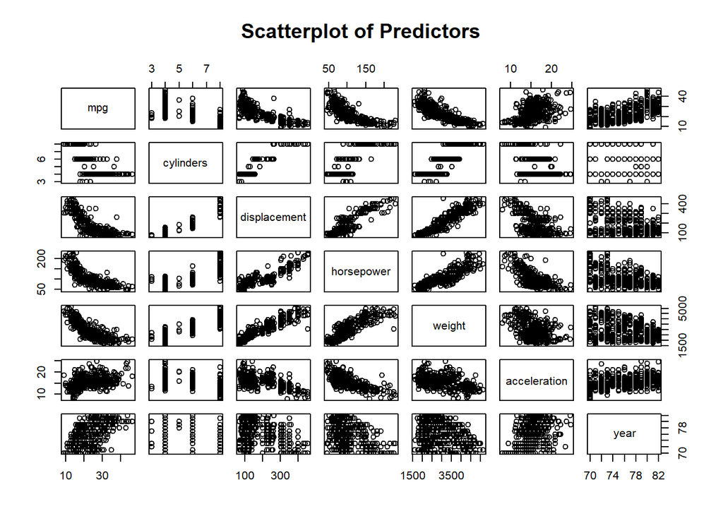

```r
pairs(Auto[, quantitative_indexs], main = "Scatterplot of Predictors")
```

My comment: Horsepower, Weight, and Displacement are positively correlated with each other, showing that cars with larger engines tend to be heavier and have higher horsepower.Cylinders is reflected in the horizontal lines in some plots, such as against MPG or displacement, indicating that certain values (4, 6, 8 cylinders) are dominant.

To observe the distribution of mpg across different cylinder categories:

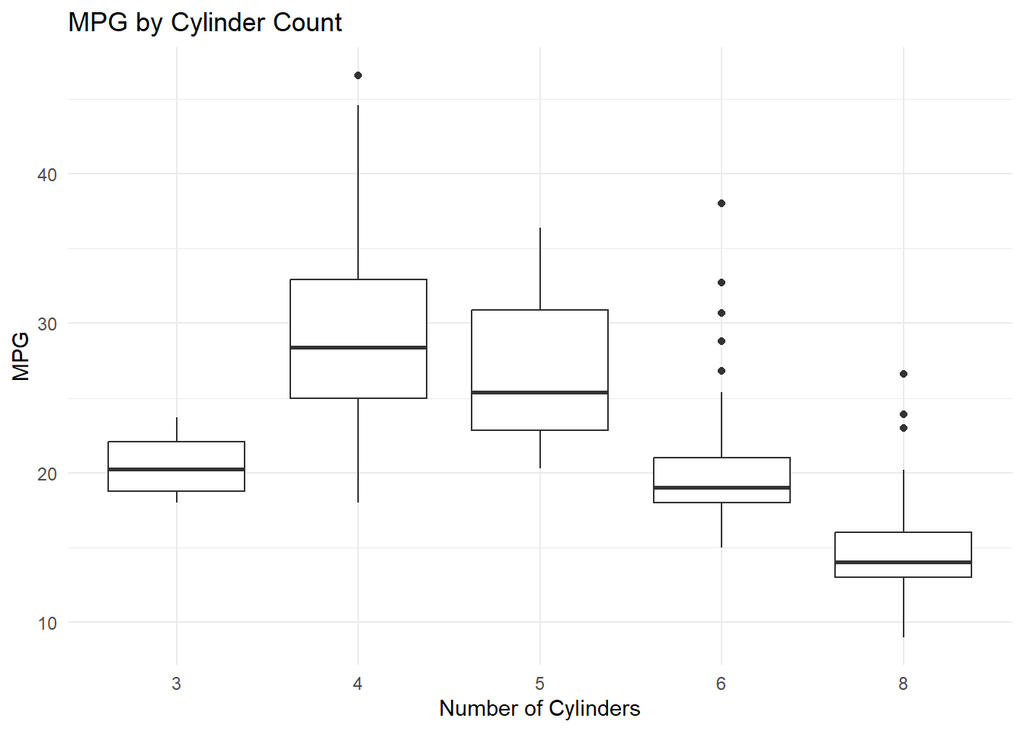

```r
ggplot(Auto, aes(x = as.factor(cylinders), y = mpg)) +
  geom_boxplot() + labs(x = "Number of Cylinders", y = "MPG", title = "MPG by Cylinder Count") + theme_minimal()
```

To visualize how fuel efficiency (mpg) relates to horsepower:

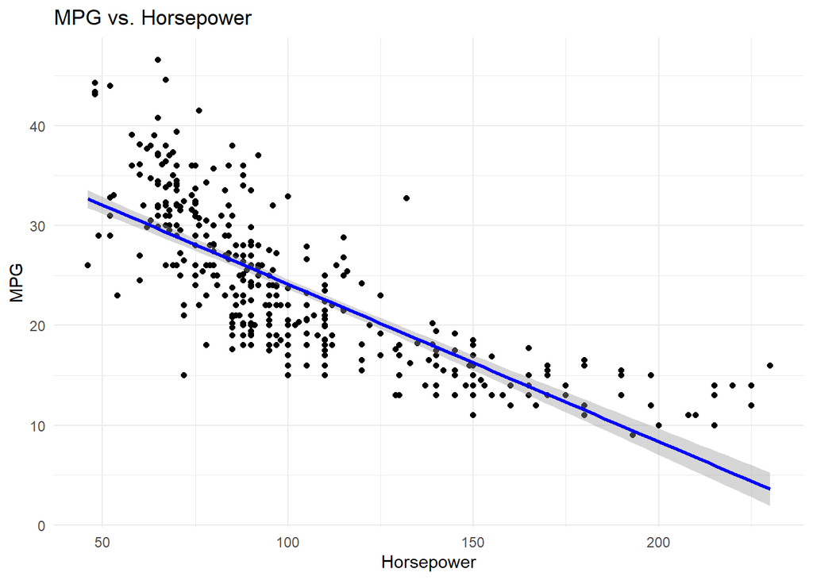

```r
ggplot(Auto, aes(x = horsepower, y = mpg)) +
  geom_point() + geom_smooth(method = "lm", color = "blue") +
  labs(x = "Horsepower", y = "MPG", title = "MPG vs. Horsepower") +
  theme_minimal()
```

My comment: As horsepower increases, MPG decreases, indicating that more powerful cars generally consume more fuel.